# Análise do Impacto da Pandemia no Bem-Estar Psicológico Infantil

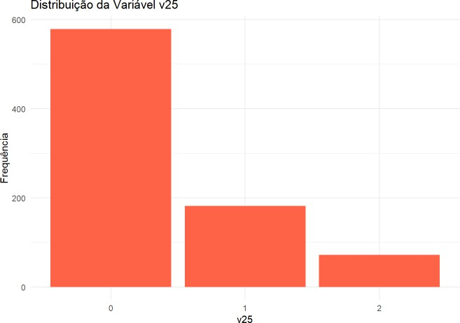

A distribuição das respostas à variável v25 “Enerva-se muito facilmente e faz muitas birras” mostra que: • Cerca de 69% dos alunos consideram que esta afirmação não é verdade. • 22% afirmam que é pouco verdade. • E aproximadamente 9% dizem que é muito verdade.

Embora a maioria dos alunos não se identifique com este comportamento de irritação e birras frequentes, é importante destacar que quase 1 em cada 10 manifesta que este comportamento é muito presente. Este resultado pode indicar sinais de regulação emocional mais frágeis num grupo específico de crianças, sendo um aspeto relevante para futuras intervenções ou monitorização, sobretudo tendo em conta o contexto pós- pandemia, onde podem ter surgido certos tipos de trauma.

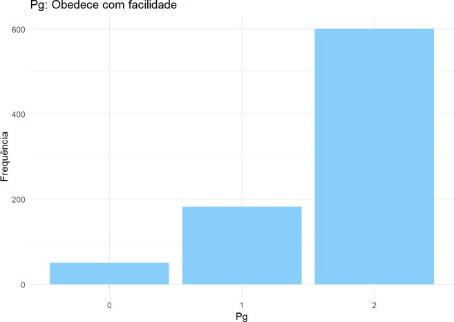

A distribuição das respostas à variável Pg “Obedece com facilidade, faz habitualmente o que os adultos lhe mandam” mostra que: • 73% dos alunos consideram que esta afirmação é muito verdade, ou seja, afirmam que obedecem com facilidade. • Cerca de 22% consideram que é pouco verdade. • Apenas cerca de 6% dizem que não é verdade. Este resultado revela que a maioria dos alunos parece apresentar um comportamento de obediência e respeito pelas orientações dos adultos, o que pode ser interpretado como um sinal positivo no contexto de socialização e adaptação às rotinas escolares. No entanto, o grupo dos 6% que refere não obedecer com facilidade pode necessitar de uma atenção adicional, sobretudo em ambientes educativos e familiares, o que também pode estar relacionado com a pandemia, devido á privatização dos indivíduos para não espalhar a doença, tornando cada jovem um bocado mais autónomo.

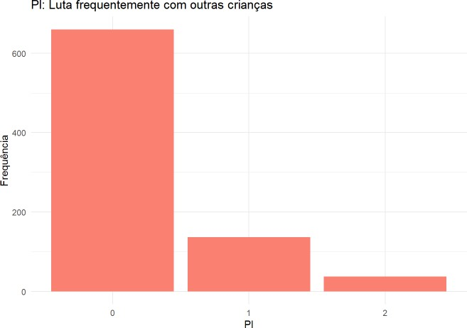

A distribuição das respostas à variável Pl “Luta frequentemente com as outras crianças, ameaça-as ou intimida-as” mostra que: • 79% dos alunos consideram que esta afirmação não é verdade. • Cerca de 16% dizem que é pouco verdade. • Apenas 4% afirmam que é muito verdade. Estes resultados são positivos, na medida em que a esmagadora maioria dos alunos não se identifica com os comportamentos de agressividade, intimidação ou conflito com outras crianças. Ainda assim, é importante notar que cerca de 1 em cada 20 identifica-se com este tipo de comportamentos, o que pode ser indicativo de dificuldades de regulação emocional, impulsividade ou problemas no ambiente social e familiar. Estes casos em específico devem ser acompanhados de perto, especialmente num contexto pós-pandémico onde as relações interpessoais podem ter sido afetadas e devem ser trabalhadas para serem restruturadas caso necessário.

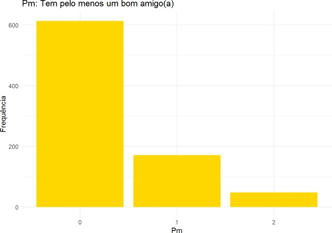

A distribuição das respostas à variável Pm “Tem pelo menos um bom amigo ou boa amiga” mostra que: • Cerca de 75% dos alunos afirmam que esta afirmação não é verdade, ou seja, não reconhecem ter pelo menos um bom amigo ou uma boa amiga. • Cerca de 21% indicam que é pouco verdade. • Apenas 6% consideram que é muito verdade, ou seja, que têm claramente um ou mais bons amigos. Esta distribuição levanta uma preocupação importante, uma vez que uma percentagem significativa dos alunos parece não ter relações próximas e significativas com os seus colegas. Em contexto de desenvolvimento infantil, a existência de amizades é um fator essencial para o bem-estar emocional, o que torna este dado um sinal de alerta, especialmente no período pós-pandemia em que as interações sociais foram fortemente afetadas, onde a única forma de interação com pessoas fora da sua habitação era online.

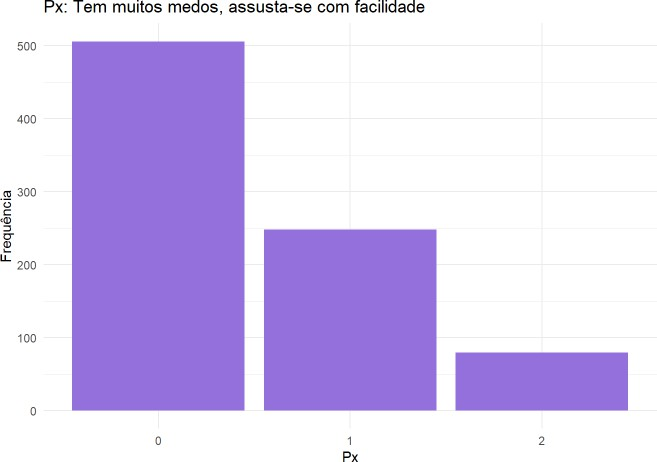

A distribuição das respostas à variável Px “Tem muitos medos, assusta-se com facilidade” mostra que: • Cerca de 60% dos alunos indicam que esta afirmação não é verdade. • Cerca de 30% referem que é pouco verdade.

- Aproximadamente 10% consideram que é muito verdade, ou seja, assumem que têm muitos medos e se assustam com facilidade. Ou seja, apesar de a maioria dos alunos não apresentar sintomas de medo excessivo ou de certa forma uma elevada ansiedade, existe um grupo não negligenciável que demonstra alguma ou muita predisposição para o medo. Este tipo de comportamentos pode estar associado a insegurança, falta de estabilidade emocional ou outros fatores psicossociais que merecem atenção, principalmente no contexto da saúde mental infantil após o isolamento social vivido durante a pandemia, devido ao próprio isolamento de cada criança numa idade tão jovem.